# NEPA Decarbonization Technology Analysis: Deliverable 6

### Final Transmission Line Sample

The 263 projects that pass all four gates form the analysis universe for length-based findings. However, NEPA duration analyses require both an initiation date and a decision date to be extractable — only 141 of the 263 projects meet this requirement. All duration statistics in this report (median review times, length–duration relationships, regional and action-type comparisons) are based on this smaller sample of 141 projects. Length-only findings (distributions, geographic patterns, action-type shares) use the full 263.

Figure 2 shows the breakdown of the 263 projects by date availability.

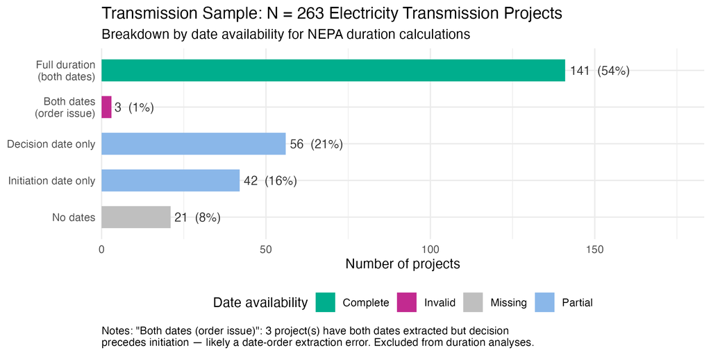

Figure 2: Breakdown of electricity transmission projects by date availability. Projects with both an initiation and decision date contribute to NEPA duration analyses; partial or missing dates limit those projects to length-based analyses only.

## Length Distribution

Figure 3 shows the full distribution of extracted transmission line lengths. The distribution is heavily right-skewed: the majority of projects involve short line segments of 25 miles or less, while a small number of large-scale projects extend well beyond 100 miles. The dashed line marks the median.

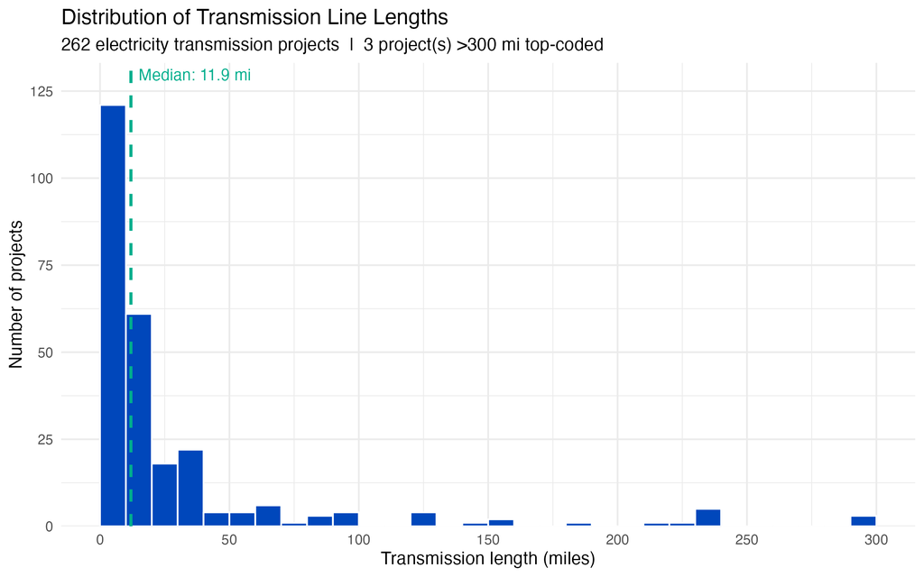

Figure 3: Distribution of extracted transmission line lengths (miles) for decarbonization technology projects. Dashed line marks the median.

## Length vs. NEPA Duration

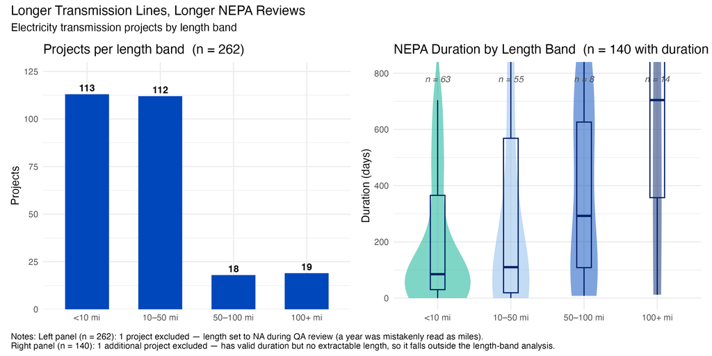

Figure 4: Left: number of electricity transmission projects by length band. Right: distribution of NEPA review duration by length band (violin shows density; box shows IQR; y-axis capped at 800 days). Longer lines show wider and higher distributions.

Table 1: Project counts and duration statistics by transmission line length band.

| Length band | Projects | Median length (mi) | Median duration (days) | P90 duration (days) |
| --- | --- | --- | --- | --- |
| <10 mi | 113 | 3.2 | 82.0 | 684.0 |
| 10–50 mi | 112 | 20.0 | 110.0 | 1,146.8 |
| 50–100 mi | 18 | 65.0 | 292.5 | 746.7 |
| 100+ mi | 19 | 220.0 | 704.5 | 2,480.0 |

Figure 5 plots each project’s extracted line length against its NEPA duration. The dark blue trend line shows the overall linear relationship. There is a positive association — longer lines tend to have longer reviews — but the correlation is modest, and many short projects still take substantial time.

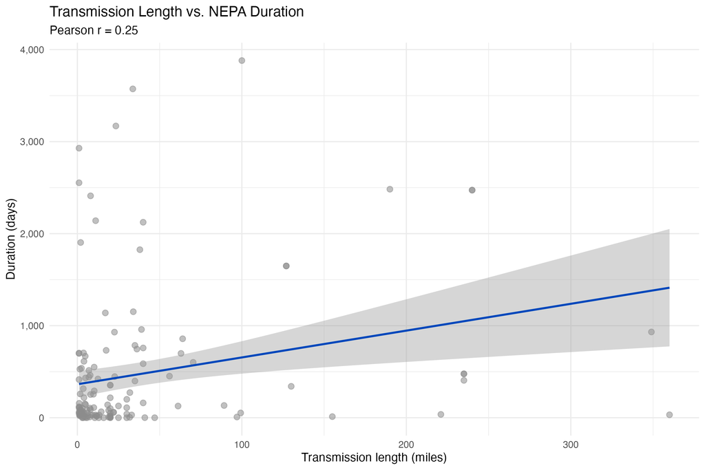

Figure 5: Transmission line length vs. NEPA duration. Dark blue line shows overall linear trend; Pearson r in subtitle.

## Geographic Patterns

Figure 6 and Figure 7 decompose the transmission sample across states. The first figure shows which states have the most projects; the second shows which states have the longest median line lengths. The two pictures are related but distinct — states with many projects are not necessarily those with the longest lines.

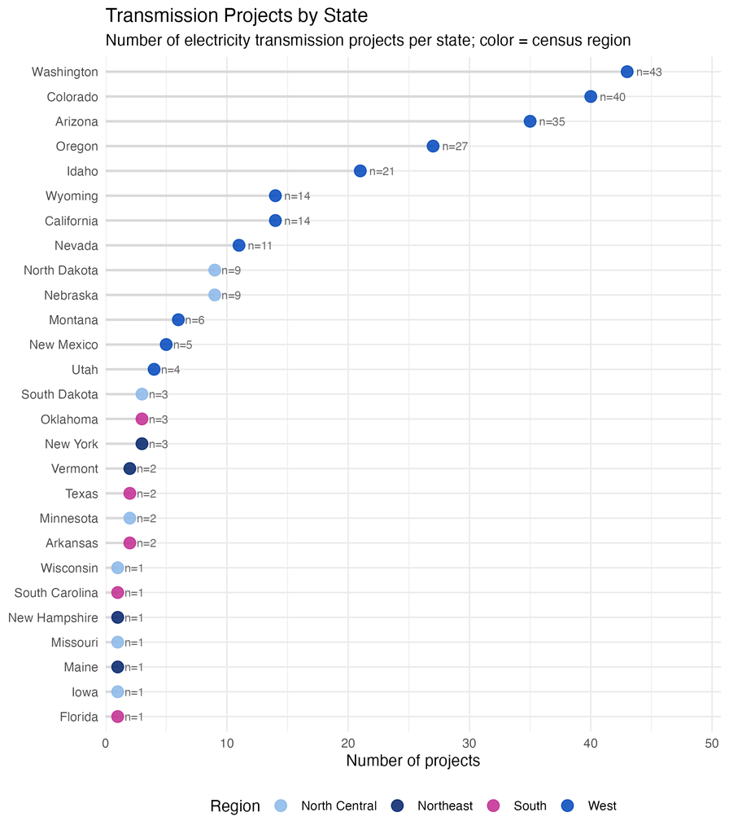

Figure 6: Number of electricity transmission projects per state, colored by census region. Labels show project count.

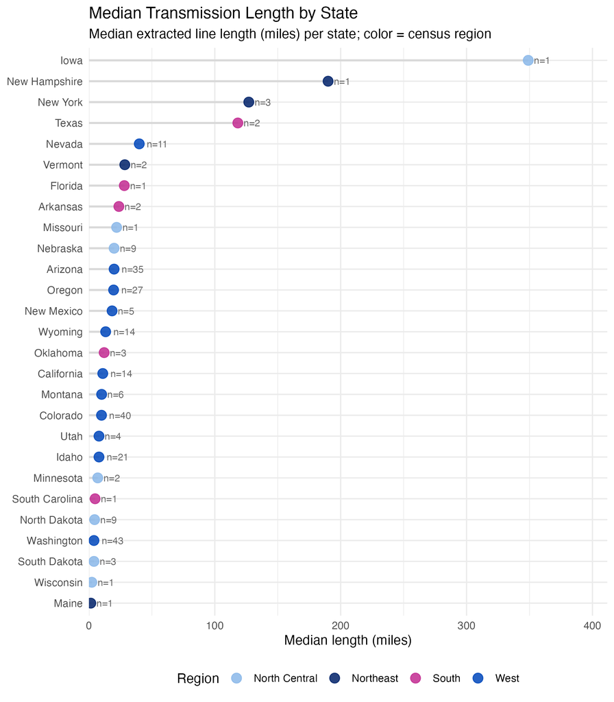

Figure 7: Median extracted line length (miles) per state. Labels show project count. Colored by census region.

## Project Action Type

The `project_transmission_action` field classifies each project’s primary activity using keyword patterns applied to the project title and description. Five categories appear in the figures:

- **New Build**: explicit construction language — e.g., *“construction of a new 230 kV transmission line”* or *“new substation.”*
- **Upgrade**: reconductoring, uprating, or capacity expansion of an existing line — e.g., *“reconductor existing 69 kV line”* or *“voltage uprate to 138 kV.”*
- **Acquisition**: land or right-of-way purchase without construction — e.g., *“right-of-way acquisition”* or *“land purchase for corridor.”*
- **Mixed**: the document matched keywords for more than one action type. These are typically multi-component projects involving both new infrastructure and modifications to existing facilities.
- **Unknown / None**: no action-type keyword was detected. The project passed the transmission build-text gate but its description lacks sufficient language to assign a specific activity.

Figure 8 shows project counts by action type. Figure 9 and Figure 10 show how line length and NEPA duration vary across categories; both figures top-code at 300 mi and 1,200 days respectively so that the box shapes are visible — a small number of outliers beyond those thresholds are hidden but included in the underlying statistics.

Upgrades are the most common classified activity, reflecting the active reconductoring and maintenance of the existing grid. Mixed projects are also frequent, suggesting many NEPA actions cover both new construction and modifications to existing facilities. New builds are relatively rare. The Unknown and None categories together account for a substantial share, consistent with many short project descriptions in the dataset that do not include explicit build-type language.

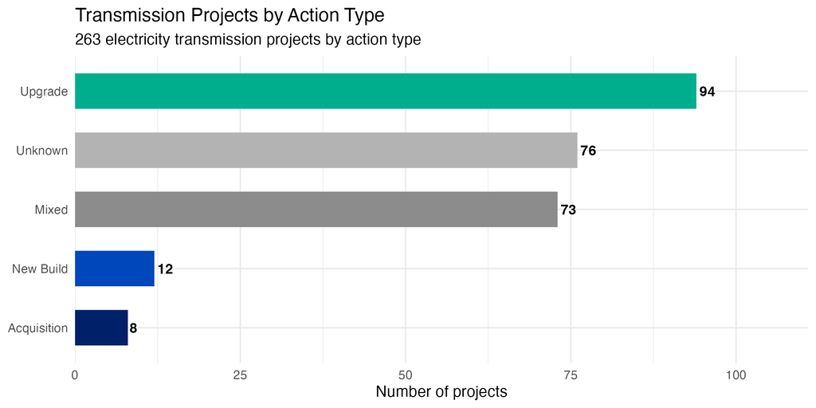

Figure 8: Count of electricity transmission projects by action type. Mixed = matched multiple action-type signals; Unknown/None = no detectable action signal.

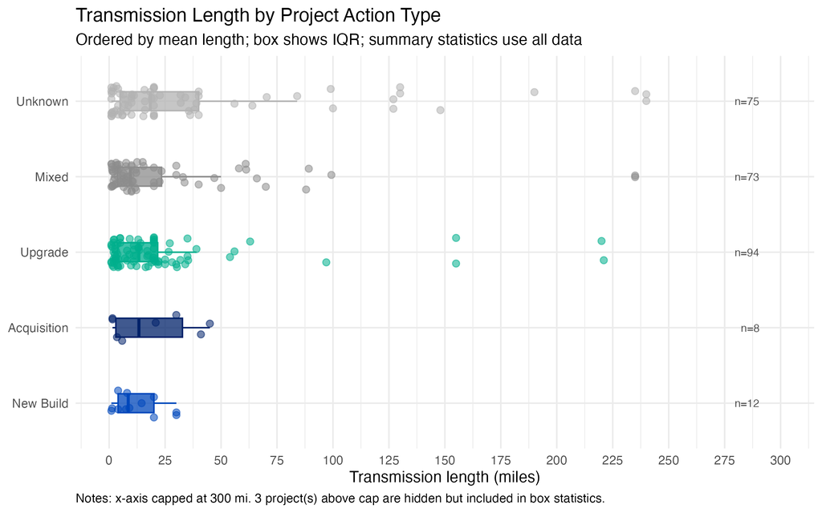

Figure 9: Transmission line length by project action type. Ordered by mean length. Boxes show IQR; points are individual projects colored by action type.

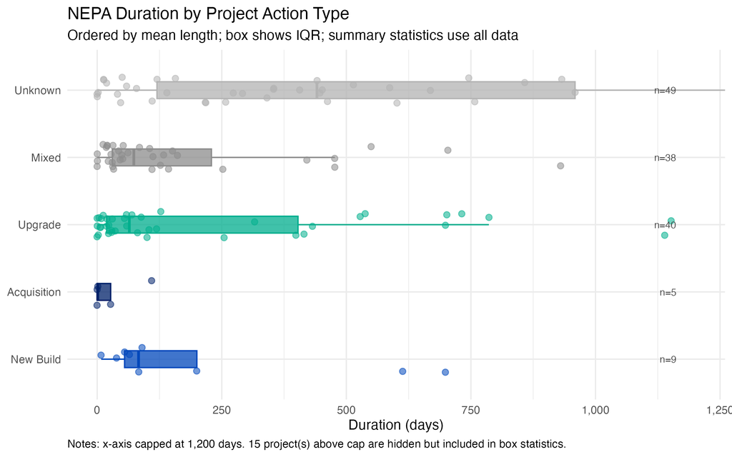